# Метрики биоразнообразия донных сообществ в условиях изменений экологической лицензии

## Постановка проблемы

Для проведения мониторинга сообществ необходимо разработать метрики, отражающие изменение биоразнообразия. Предполагается, что в основе заключений будут лежать повторяющиеся с определенной периодичностью описания сообществ (мониторинг). В случае с бентосными сообществами - взятие количественных проб на некоторой стандартной сети станций. Необходимо разработать подходы к оценке изменений, которые давали бы информацию об изменениях минимально зависящую от статистического шума, связанного с неучтенными исследователями факторами.

Самый очевидный подход заключается в сравнении “сырых” данных, полученных в один из сезонов, с данными, полученными в другой сезон наблюдения. Этот подход прост и позволяет быстро выявить изменения в каких-то комплексных параметрах, например, в общей биомассе сообщества (далее такие метрики будем обозначать, как **Метрики 1 типа**). Однако такой подход имеет ряд недостатков. Во-первых, даже при очень высокой точности позиционирования станций, разброс их расположения может достигать нескольких метров. Это потенциально может привести к тому, что новое описание будет отличаться от предыдущего вследствие пространственных, а не временных, отличий сообществ в двух точках взятия проб. Пространственные различия будут приняты за временные. Во-вторых, сообщество может быть, в целом, устойчиво, но демонстрировать флуктуации с частотой меньше периода мониторинга. При проведении переописания сообществ отбор проб может попасть в иную фазу, нежели предыдущее описание. В итоге различия между двумя выборками могут быть трактованы как следствие какого-то антропогенного воздействия, которого на самом деле не было. Этот механизм появления ложноположительных результатов может работать не только в отношении сообщества, но и в отношении абиотических параметров. Например, соленость может, в целом, закономерно изменяться в пространстве, формируя стабильный градиент. Однако в результате нагонных ветров, приливно-отливных циклов и т.п. соленость, измеренная в один период мониторинга может отличаться от солености, измеренной в другой период наблюдений.

В связи с этим, более перспективным видится иной подход. Кратко его суть сводится к тому, чтобы проведя отбор проб в год $t$, получить модель, описывающую связь каких-то показателей сообщества с параметрами биотопа. Показатели сообщества могут быть как одномерные (общая численность, общая биомасса, индексы видового разнообразия), так и многомерные (матрица обилий отдельных видов). Параметры биотопа представлены в виде градиентов условий среды, в которых формируется сообщество. Такие градиенты принято называть экологической лицензией. Модель, описывающая связь сообщества с лицензией, будет предсказывать некоторую ожидаемую структуру сообщества в рамках данной лицензии. При повторном наблюдении в год $t+1$ такая модель должна быть построена вновь. При сравнении сообществ, описанных в год $t$ и $t+1$, сравниваться должны предсказания двух моделей. Статистическая значимость различий будет оцениваться на основе оценки соотношений предсказанных моделями величин и величины остатков. На практике для вынесения суждения об изменениях в сообществах будет строится не две независимые модели, а одна, в которой будет рассматриваться связь биотического показателя с парамтерами среды и в качестве дискретного предиктора будет включен период сбора материала. В простейшем случае, когда анализируемая величина представлена одномерным вектором значений а из всех параметров среды рассматривается только один фактор, анализ сводится к построению стандартной общей линейной модели (general linear model). В этой модели непрерывным предиктором выступает фактор среды, а дискретным предиктором - период сбора ($t$ vs $t+1$). Такие метрики далее будем обозначать, как **Метрики 2 типа**.

Любое воздействие (антропогенное, климатическое и т.п.), если оно достаточно мощное, приводит изменению экологической лицензии биотопа. В результате изменения экологической лицензии происходит изменение и структуры сообщества, которое проявляется не только в изменении обилия популяций отдельных видов в соответствии с их экофизиологическими реакциями на факторы среды, но и в изменении характера взаимоотношений между членами сообществ. Последнее тоже может привести к существенным изменениям обилия популяций отдельных видов из-за повышения/снижения межвидовой конкуренции или повышения/понижения интенсивности трофических связей. Указанное обстоятельство заставляет моделировать поведение сообщества целиком, как изменение некоторой многомерной функции в ответ на изменение лицензии. Для построения подобных моделей адаптирована концепция Joint Species Distribution Modelling (JSDM). Метрики, основанные на таком подходе будем обозначать, как **Метрики 3 типа**.

## Метрики 1 типа

Для оценки изменений, сообщество “редуцируется” до некоторой одномерной величины, которая может быть оценена в каждой пробе. Наиболее очевидные показатели: суммарная биомасса бентоса ($B_{total}$), суммарная численность всех организмов ($N_{total}$) или один из индексов видового разнообразия (Diversity index). В качестве поcледнего наиболее удобен индекс Шеннона:

$$H = -\sum{\frac{N_i}{N_{total}}log_2(\frac{N_i}{N_{total}})}$$

Любой их этих показателей может быть получен для каждой пробы. Далее эти показатели усредняются для $t$ и $t+1$. Различия средних могут быть выражены в процентах от начльного состояния. Если есть необходимость статистических сравнений, то они могут быть проведены с помощью t-критерия Стьюдента.

## Метрики 2 типа

Для этих метрик сообщество также должно быть редуцировано до тех же обобщенных величин, что и в предыдущем случае. Однако для применения этого подхода пробы должны быть взяты, в некотором градиенте среды, который характеризует экологическую лицензию. Например, в случае Обской губы очевидным фактором должен быть градиент солености. То есть, при планировании мониторинга станции должны быть расположены так, чтобы они попадали и в разные участки градиента солености, которая закономерно увеличивается с юга на север. Чем больше предикторов будет включено в модель, тем точнее будет оценка изменений при сравнении периодов $t$ и $t+1$.

**NB** *В связи с тем, что одним из потенциальных факторов, приводящих к изменениям могут быть антропогенные влияния (суть которых предсказать невозможно) важным предиктором в такой модели может быть расстояние до ближайшего источника потенциального влияния (например до порта “Сабетта” или терминала “Утренний”). При этом важно, чтобы указанный предиктор на был коллинеарен другим предикторам, включенным в модель (например, солености). Для этого сеть мониторинговых станций должна быть организована так, чтобы варьирование расстояния до ближайшего участка антропогенного воздействия не совпадало с варьированием другого фактора (например солености).*

Для оценки величины изменений в период $t+1$ по сравнению с периодом $t$ необходимо будет вычислить предсказанные моделью величины для каждой из станций в оба периода. Далее можно оценить степень различий на каждой из станций или в среднем на всем массиве данных. Эти различия могут быть выражены в процентах по отношению к начальному периоду наблюдений.

Если есть необходимость статистических сравнений, то они могут быть проведены с помощью стандартной процедуры ANCOVA. Графическим отражением модели могут быть линии регрессии, отражающие связи изучаемой характеристики с параметрами среды, включенными в модель. Если изменения в $t+1$ по сравнению с $t$ несущественны, то линии регрессии должны совпасть.

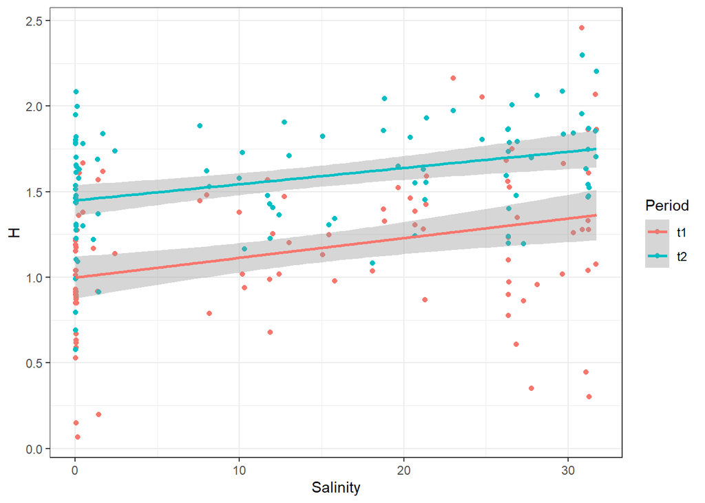

В данном случае характер связи с параметрами среды не изменился, а видовое разнообразие в период 2 возросло и отличается от видового разнообразия в период 1, в среднем, на 37.5 %.

## Метрики 3 типа

### Теоретические посылки

В теоретической экологии сообщество предстает в виде системы реализованных экологических ниш, упакованных в рамках лицензии. Характер связи вида с параметрами среды (экологическая ниша) может быть описан коэффициентами регрессионной модели, устанавливающей связь обилия вида со значениями факторов среды. В простейшем случае, когда рассматривается один фактор среды и один вид, обилие которого линейно связано с данным фактором, ниша данного вида может быть охарактеризована значениями коэффициентов следующей модели:

$$N = b_0 + b_1F + \varepsilon$$

$b_0$, или intercept, характеризует общий уровень обилия вида; $b_1$, или slope, характеризует связь обилия вида с фактором (F); $\varepsilon$ - неучтенные моделью отклонения (остатки).

В более сложных вариантах модель может включать большее число коэффициентов.

Стало быть для характеристики реализованной ниши отдельного вида в рамках экологической лицензии необходимо указать значения коэффициентов $b_0$ и $b_1$. Графическим выражением этой связи будет являться линия регрессии, построенные для каждого вида.

Представим себе, что коэффициенты $b_0$ и $b_1$ были оценены в год $T_1$, когда экологическая лицензия данного биотопа, характеризовалась диапазоном единственного фактора $DF_1$. Если в год $T_2$ значения фактора изменились (например увеличились), то лицензия в данный год будет отражаться величиной $DF_2$. Если при этом коэффициенты $b_0$ и $b_1$ не изменились, то есть характер связи единственного вида с единственным фактором, остался прежним, то это означает, что значительных изменений в отношении данного вида с его биотопом не произошло. Если же значения коэффициентов существенно изменились, то мы можем констатировать существенное влияние этих изменений на реализованную экологическую нишу вида. Графически это изменение может быть выражено в виде двух регрессионных прямых. При первом сценарии эти прямые совпадают, при втором - нет.

Такая трактовка экологической ниши (набор коэффициентов регрессионных моделей) позволяет формализовать процедуру прогноза изменений при изменении экологической лицензии (то есть при некоторых воздействиях, повлекших изменение значений фактора $F$). Если реализованная ниша вида не изменяется, то прогноз строится простой экстраполяцией имеющейся модели на новые значения фактора. Качество прогноза зависит только от качества оценок. Если же коэффициенты меняются, то прогнозы возможны только если мы знаем (или задаем) правило, по которому происходит это изменение.

Если мы рассматриваем не один вид, а все сообщество целиком, то в рамках концепции JSDM подбор коэффициентов, описывающих реализованные ниши, осуществляется не для каждого вида в отдельности (как серия независимых линейных моделей), а с учетом связей между видами (матрица корреляций) и учетом дизайна сбора материала (наличие случайных группирующих факторов и/или факторов, порождающих пространственные или временные автокорреляции). Потенциально в рамках JSDM можно учесть и филогенетические и функциональные характеристики видов. Однако логика анализа будет более или менее сходной с той, что описана выше для случая одного вида и одного фактора.

Моделирование связи всего сообщества в целом с факторами лицензии дает еще более гибкий инструмент для оценки влияния тех или иных воздействий на сообщество. Принципиально схема анализа будет такой же, как при работе с метриками 2 типа:

1. Мы строим модель, описывающую связь всего сообщества с ключевыми факторами среды, в модель должен быть фактор “Период”.
2. Получаем предсказания модели для каждого из двух периодов. Программы, позволяющие строить JSDM, позволяют сформировать матрицу предсказанных обилий видов.
3. Оцениваем различия двух предсказаний. При этом матрицы предсказанных обилий видов можно свернуть в комплексные показатели, например в индекс Шеннона.

Моделирование с помощью JSDM дает и еще один инструмент. Этот подход позволят дать оценки изменениям в структуре сообществ, ожидаемым при разных сценариях преобразования биотопа. Например, при проведении гидротехнических мероприятий, которые известным образом изменят условия существования сообществ. Продемонстрируем возможности JSDM для оценки изменений, которые могли быть вызваны в бентосных сообществах Обской губы.

## Моделирование изменений в Обской губе

$$Dif = S_{Constructed} - S_{Native}$$

Положительное значение будет означать рост солености при проведении гидротехнических работ, отрицательное значение - падение солености.

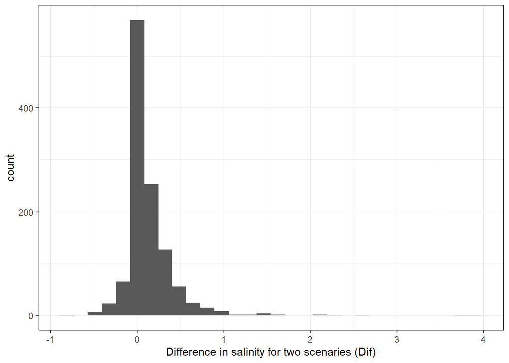

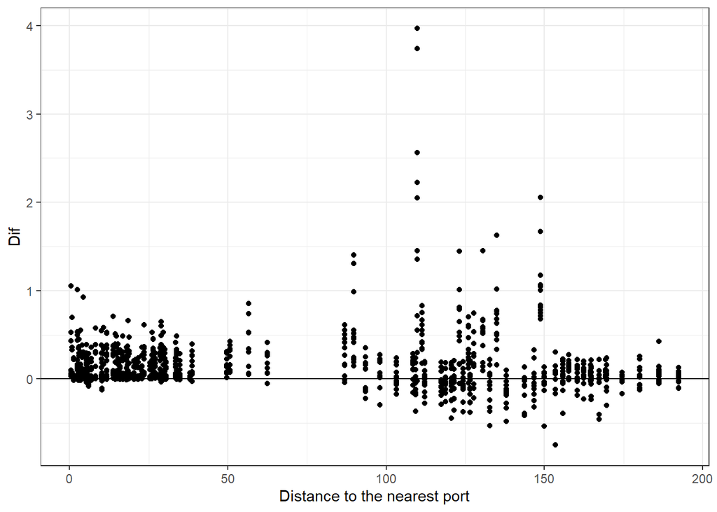

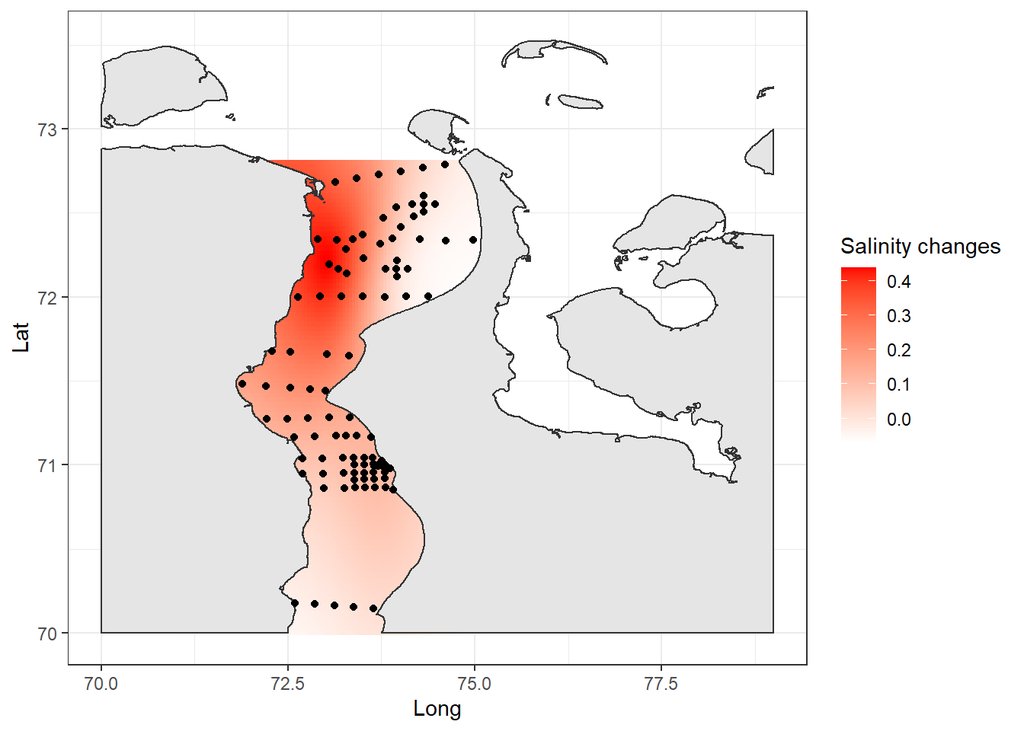

Продемонстрируем подход, основанный на JSDM, для ответа на вопрос какие изменения структуре сообществ ожидаются при сценарии “Constructed” по сравнению со сценарием “Native”. Эти два сценария подразумевают некоторые изменения экологической лицензии акватории. Суть изменений описана выше.

$$ln(N) = b_0 + b_1S + b_2S^2 + \varepsilon$$

Для построения модели в качестве показателя обилия будет использован логарифм от плотности поселения вида, $ln(N) + 1$, (это необходимо для построения модели, основанной на нормальном распределении). Подбор коэффициентов модели осуществлялся с помощью пакета “Hmsc” (Tikhonov, Ovaskainen, Oksanen, 2021).

Если рассматривать данную модель в качестве точки отсчета, то можно рассчитать “ожидаемое сообщество” при двух сценариях.

Если теперь описать сообщества, предсказанные для двух сценариев, с помощью индекса Шеннона, то можно для каждой станции оценить возросло или упало видовое разнообразие. Для этого введем величину $Dif_H$, которая показывает на сколько процентов отличается индекс Шеннона в данной станции при сценарии “Constructed” от аналогичного индекса при сценарии “Native”.

$$Dif_H = \frac{H_{Constructed} - H_{Native}}{H_{Native}}\cdot 100 \%$$

Положительное значение $Dif_H$ говорит о повышении разнообразия, отрицательное - о его понижении.В среднем по всей акватории видовое разнообразие при разных сценариях изменяется незначительно, на 0.2585%. То есть строительство гидросооружений приводит к небольшому повышению видового разнообразия. Более детальную картину дает анализ пространственного распределения величины $Dif_H$.

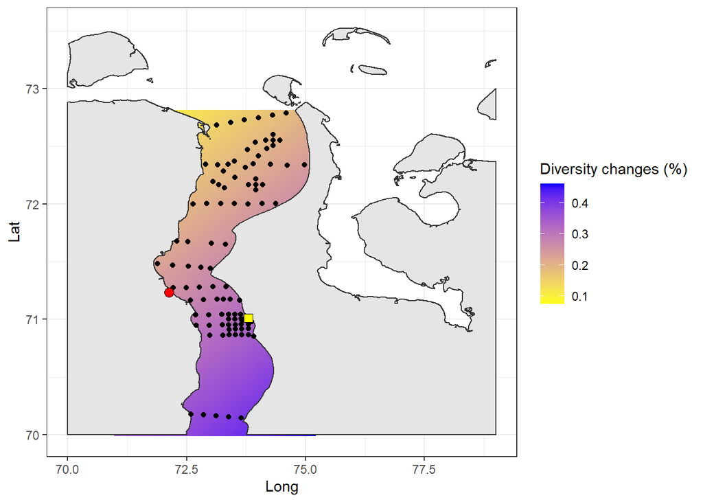

Видно, что наиболее сильное изменение разнообразия прогнозируется в южной, самой опресненной, части акватории. Здесь при реализации сценария “Constructed” видовое разнообразие вырастет по сравнению с таковым при сценарии “Native”. Морская часть акватории при проведении гидротехнических работ испытает меньшие изменения.

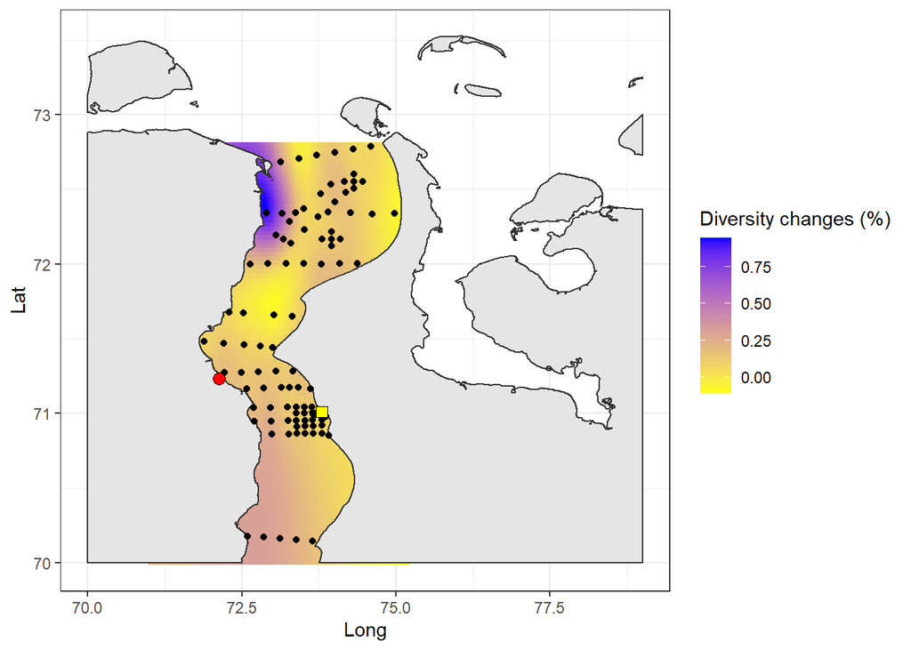